# Example visualization

```r
library(data.table)  ## for fast fread()
library(ggplot2)  ## nice plots
theme_set(theme_bw())  ## cosmetic
library(KernSmooth)
```

Read data, organize, merge:

```r
fn <- "ex1"
hdat <- fread(paste0(fn, ".household.csv"))
```

```
##
0%
```

```r
idat <- fread(paste0(fn, ".individual.csv"))
```

```
##
0%
```

```r
## should be unnecessary once flat files have column headings
setnames(idat, names(idat), c("hID", "sex", "age", "disStatus"))
setnames(hdat, names(hdat), c("hID", "x", "y", "income", "disRisk"))
## key both data sets on household ID and merge
setkey(hdat, hID)
setkey(idat, hID)
idat2 <- merge(hdat, idat)
```

R's plotting capabilities are not actually so great for dealing with very large data sets (these count as “somewhat large”) – we really need to summarize in some efficient way first, then plot …

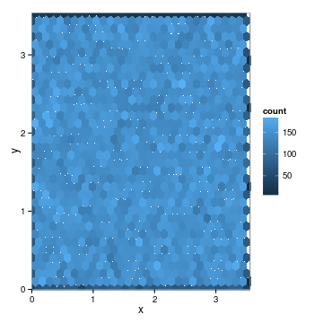

```r
## plot(y~x,data=hdat,pch='.') ## not very informative!!
## with(hdat,plot(hexbin(x,y))) ## efficient but ugly nice except for edge
## effects ...
ggplot(hdat, aes(x, y)) + geom_hex() + scale_x_continuous(expand = c(0, 0)) +
    scale_y_continuous(expand = c(0, 0))
```

What we really want is to do hexagonal binning or kernel density estimation to get a reasonable smoothed version of the variable of interest (income, disease risk, etc.) so we can map it. I think in this case everything's going to be pretty boring since we haven't built in very much interesting spatial variation yet …

Hexagonal binning is nice; I need to work out [this solution](http://stackoverflow.com/questions/17688012/hexbin-apply-function-for-every-bin) and then see if I can feed it `ggplot2::geom_hex` for prettier output …

```r
hex1 <- hexbin(idat2$x, idat2$y, IDs = TRUE)
```

Kernel smoothing:

```r
kk <- bkde2D(hdat[, list(x, y)], bandwidth = c(0.1, 0.1))
```

Base contour plot (nothing going on here!)

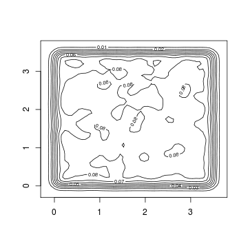

```r
with(kk, contour(x1, x2, fhat))
```

```r
brks <- seq(min(hdat[, x]), max(hdat[, x]), length = 51)
## and := to avoid an additional copy (can this be done in a single step?)
idat2[, `:=`(xbin, findInterval(x, brks))]
idat2[, `:=`(ybin, findInterval(y, brks))]
```

Aggregate with mean by bin; use `.N` to include number of elements per bin, and plot.

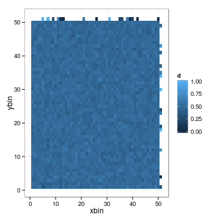

```r
idatsum <- idat2[, list(.N, d = mean(disStatus)), by = list(xbin, ybin)]
ggplot(idatsum, aes(xbin, ybin)) + geom_tile(aes(fill = d))
```

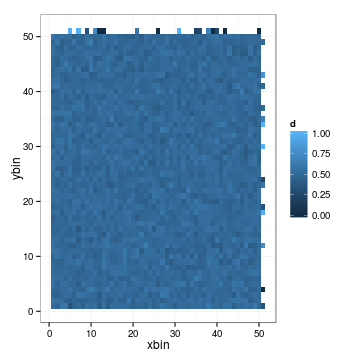

```r
hdatsum <- idat2[, j = list(x = x[1], y = y[1], .N, dsum = sum(disStatus)),
    by = hID]
ggplot(idatsum, aes(xbin, ybin)) + geom_tile(aes(fill = d))
```

Zoom in on a region:

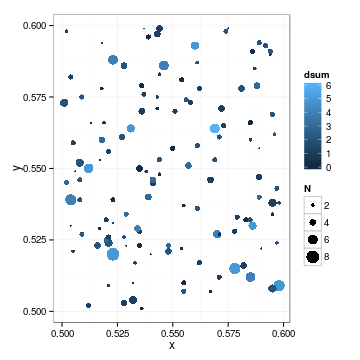

```r
hdatfoc <- hdatsum[0.5 < x & x < 0.6 & 0.5 < y & y < 0.6, ]
ggplot(hdatfoc, aes(x, y)) + geom_point(aes(size = N, colour = dsum))
```

## To do

### Pix

- hexbin plots? of income, disease risk, …
- associations of covariates – disease vs gender, age, income, etc.
- check out `bigvis` package?

### Data manipulation

- could compute household averages of disease, for faster plotting (should be easy with `data.table`)

### Cosmetics

- get rid of `fread` progress bars
- fix `findInterval` edge cases?